# Hoja de Ejercicios 2

## Exercice 4

**This exercise involves the Auto data set studied in the lab. Make sure that the missing values have been removed from the data.**

```r
auto = read.csv("Auto.csv")
```

Después de importar los datos del fichero, realizamos un pequeño análisis de los datos mediante:

```r
summary(auto)
```

```
##       mpg          cylinders      displacement     horsepower
##  Min.   : 9.00   Min.   :3.000   Min.   : 68.0   150    : 22
##  1st Qu.:17.50   1st Qu.:4.000   1st Qu.:104.0   90     : 20
##  Median :23.00   Median :4.000   Median :146.0   88     : 19
##  Mean   :23.52   Mean   :5.458   Mean   :193.5   110    : 18
##  3rd Qu.:29.00   3rd Qu.:8.000   3rd Qu.:262.0   100    : 17
##  Max.   :46.60   Max.   :8.000   Max.   :455.0   75     : 14
##                                                  (Other):287
##      weight      acceleration        year           origin
##  Min.   :1613   Min.   : 8.00   Min.   :70.00   Min.   :1.000
##  1st Qu.:2223   1st Qu.:13.80   1st Qu.:73.00   1st Qu.:1.000
##  Median :2800   Median :15.50   Median :76.00   Median :1.000
##  Mean   :2970   Mean   :15.56   Mean   :75.99   Mean   :1.574
##  3rd Qu.:3609   3rd Qu.:17.10   3rd Qu.:79.00   3rd Qu.:2.000
##  Max.   :5140   Max.   :24.80   Max.   :82.00   Max.   :3.000
##
##              name
##  ford pinto    :  6
##  amc matador   :  5
##  ford maverick :  5
##  toyota corolla:  5
##  amc gremlin   :  4
##  amc hornet    :  4
##  (Other)       :368
```

```r
names(auto)
```

```
## [1] "mpg"          "cylinders"    "displacement" "horsepower"
## [5] "weight"       "acceleration" "year"         "origin"
## [9] "name"
```

```r
head(auto, 100)
```

| mpg | cylinders | displacement | horsepower | weight | acceleration | year | origin | name |
| --- | --- | --- | --- | --- | --- | --- | --- | --- |
| 18 | 8 | 307.0 | 130 | 3504 | 12.0 | 70 | 1 | chevrolet chevelle malibu |
| 15 | 8 | 350.0 | 165 | 3693 | 11.5 | 70 | 1 | buick skylark 320 |
| 18 | 8 | 318.0 | 150 | 3436 | 11.0 | 70 | 1 | plymouth satellite |
| 16 | 8 | 304.0 | 150 | 3433 | 12.0 | 70 | 1 | amc rebel sst |
| 17 | 8 | 302.0 | 140 | 3449 | 10.5 | 70 | 1 | ford torino |
| 15 | 8 | 429.0 | 198 | 4341 | 10.0 | 70 | 1 | ford galaxie 500 |
| 14 | 8 | 454.0 | 220 | 4354 | 9.0 | 70 | 1 | chevrolet impala |
| 14 | 8 | 440.0 | 215 | 4312 | 8.5 | 70 | 1 | plymouth fury iii |
| 14 | 8 | 455.0 | 225 | 4425 | 10.0 | 70 | 1 | pontiac catalina |
| 15 | 8 | 390.0 | 190 | 3850 | 8.5 | 70 | 1 | amc ambassador dpl |

[output cut: 90 more lines]

1. **Which of the predictors are quantitative, and which are qualitative?**

```r
str(auto)
```

```
## 'data.frame':    397 obs. of  9 variables:
##  $ mpg         : num  18 15 18 16 17 15 14 14 14 15 ...
##  $ cylinders   : int  8 8 8 8 8 8 8 8 8 8 ...
##  $ displacement: num  307 350 318 304 302 429 454 440 455 390 ...
##  $ horsepower  : Factor w/ 94 levels "?","100","102",..: 17 35 29 29 24 42 47 46 48 40 ...
##  $ weight      : int  3504 3693 3436 3433 3449 4341 4354 4312 4425 3850 ...
##  $ acceleration: num  12 11.5 11 12 10.5 10 9 8.5 10 8.5 ...
##  $ year        : int  70 70 70 70 70 70 70 70 70 70 ...
##  $ origin      : int  1 1 1 1 1 1 1 1 1 1 ...
##  $ name        : Factor w/ 304 levels "amc ambassador brougham",..: 49 36 231 14 161 141 54 223 241 2 ...
```

Las variables cuantitativas son:

- mpg
- cylinders
- displacement
- weight
- acceleration
- horsepower

Las variables cualitativas son:

- year
- origin
- name

Hay que cambiar la variable *horsepower* para que sea una variable numérica en lugar de un factor. Debido a que en los siguientes apartados hay que usar las únicamente las variables cuantitativas, se crea un dataframe con solo dichas variables:

```r
auto$horsepower = as.numeric(auto$horsepower )
auto_quantit = auto[c('mpg', 'cylinders', 'displacement', 'weight', 'acceleration', 'horsepower')]
```

2. **What is the range of each quantitative predictor? You can answer this using the range() function.**

El rango de las variables cuantitativas es:

```r
apply(auto_quantit, 2, range)
```

```
##       mpg cylinders displacement weight acceleration horsepower
## [1,]  9.0         3           68   1613          8.0          1
## [2,] 46.6         8          455   5140         24.8         94
```

3. **What is the mean and standard deviation of each quantitative predictor?**

La media de las variables cuantitativas es:

```r
colMeans(auto_quantit)
```

```
##          mpg    cylinders displacement       weight acceleration
##    23.515869     5.458438   193.532746  2970.261965    15.555668
##   horsepower
##    51.516373
```

La desviación estándar de las variables cuantitativas es:

```r
apply(auto_quantit, 2, sd)
```

```
##          mpg    cylinders displacement       weight acceleration
##     7.825804     1.701577   104.379583   847.904119     2.749995
##   horsepower
##    29.862697
```

4. **Now remove the 10th through 85th observations. What is the range, mean, and standard deviation of each predictor in the subset of the data that remains?**

```r
new_auto_data = auto_quantit[-c(10:85), ]

apply(new_auto_data, 2, range)
```

```
##       mpg cylinders displacement weight acceleration horsepower
## [1,] 11.0         3           68   1649          8.5          1
## [2,] 46.6         8          455   4997         24.8         94
```

```r
colMeans(new_auto_data)
```

```
##          mpg    cylinders displacement       weight acceleration
##    24.438629     5.370717   187.049844  2933.962617    15.723053
##   horsepower
##    50.996885
```

```r
apply(new_auto_data, 2, sd)
```

```
##          mpg    cylinders displacement       weight acceleration
##     7.908184     1.653486    99.635385   810.642938     2.680514
##   horsepower
##    30.076725
```

5. **Using the full data set, investigate the predictors graphically, using scatterplots or other tools of your choice. Create some plots highlighting the relationships among the predictors. Comment on your findings**

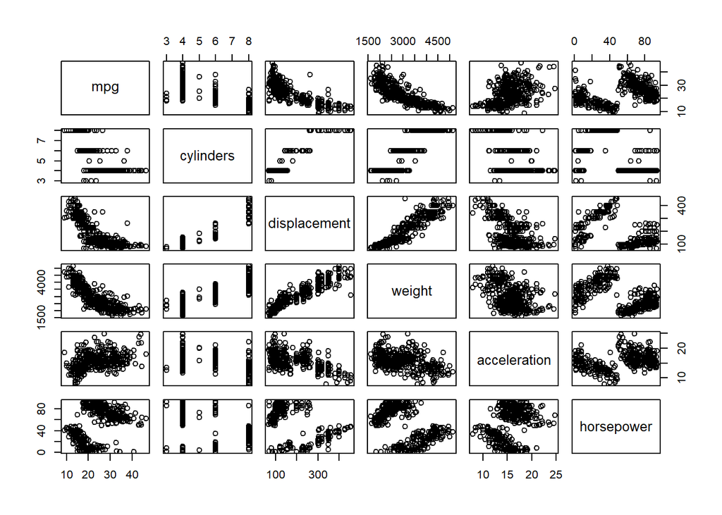

```r
pairs(auto_quantit)
```

```r
cor(auto_quantit)
```

```
##                     mpg  cylinders displacement     weight acceleration
## mpg           1.0000000 -0.7762599   -0.8044430 -0.8317389    0.4222974
## cylinders    -0.7762599  1.0000000    0.9509199  0.8970169   -0.5040606
## displacement -0.8044430  0.9509199    1.0000000  0.9331044   -0.5441618
## weight       -0.8317389  0.8970169    0.9331044  1.0000000   -0.4195023
## acceleration  0.4222974 -0.5040606   -0.5441618 -0.4195023    1.0000000
## horsepower    0.4228227 -0.5466585   -0.4820705 -0.4821507    0.2662877
##              horsepower
## mpg           0.4228227
## cylinders    -0.5466585
## displacement -0.4820705
## weight       -0.4821507
## acceleration  0.2662877
## horsepower    1.0000000
```

La variable *mpg* parece estar correlacionada con los cilindros, el desplazamiento y el peso (negativamente correlacionadas). Por otra parte, el desplazamiento para estar fuertemente correlacionado con los cilindros y el peso. No obstante, la variable que parece explicar menos las otras variables es la aceleración debido a su baja correlación.

6. **Suppose that we wish to predict gas mileage (mpg) on the basis of the other variables. Do your plots suggest that any of the other variables might be useful in predicting mpg? Justify your answer.**

Para predecir *mpg* basándonos en las otras variables, podemos utilizar un modelo de regresión lineal.

```r
lin_reg = lm(mpg ~ cylinders+weight+displacement+acceleration+horsepower, data = auto_quantit)
lin_reg
```

```
##
## Call:
## lm(formula = mpg ~ cylinders + weight + displacement + acceleration +
##     horsepower, data = auto_quantit)
##
## Coefficients:
##  (Intercept)     cylinders        weight  displacement  acceleration
##    41.458326     -0.223426     -0.006119     -0.007512      0.176534
##   horsepower
##     0.003093
```

Este resultado no nos da una clara evidencia de qué variables explican mejor *mpg*, por lo que calculamos la *anova*:

```r
anova(lin_reg)
```

| Df | Sum Sq | Mean Sq | F value | Pr(>F) |
| --- | --- | --- | --- | --- |
| 1 | 14613.94501 | 14613.94501 | 787.737722 | 1.002402e-95 |
| 1 | 2276.59402 | 2276.59402 | 122.715597 | 5.461235e-25 |
| 1 | 44.54943 | 44.54943 | 2.401355 | 1.220392e-01 |
| 1 | 61.17330 | 61.17330 | 3.297434 | 7.015398e-02 |
| 1 | 2.29827 | 2.29827 | 0.123884 | 7.250492e-01 |
| 391 | 7253.75000 | 18.55179 | NA | NA |

La *anova* nos está indicando que las variables que mejor explican *mpg* son los cilindros y el peso. No obstante, en el apartado anterior se ha comentado que el desplazamiento estaba altamente correlacionado con *mpg* pero, en este caso, no es una buena variable para predecir *mpg*. La aceleración y los caballos también se descartarían para esta predicción.

## Exercice 5

**This exercise involves the Boston housing data set.**

1. **To begin, load in the Boston data set. The Boston data set is part of the MASS library in R.**

```r
library(MASS)
```

**Now the data set is contained in the object Boston.**

```r
Boston
```

| crim | zn | indus | chas | nox | rm | age | dis | rad | tax | ptratio | black | lstat | medv |
| --- | --- | --- | --- | --- | --- | --- | --- | --- | --- | --- | --- | --- | --- |
| 0.00632 | 18.0 | 2.31 | 0 | 0.5380 | 6.575 | 65.2 | 4.0900 | 1 | 296 | 15.3 | 396.90 | 4.98 | 24.0 |
| 0.02731 | 0.0 | 7.07 | 0 | 0.4690 | 6.421 | 78.9 | 4.9671 | 2 | 242 | 17.8 | 396.90 | 9.14 | 21.6 |
| 0.02729 | 0.0 | 7.07 | 0 | 0.4690 | 7.185 | 61.1 | 4.9671 | 2 | 242 | 17.8 | 392.83 | 4.03 | 34.7 |
| 0.03237 | 0.0 | 2.18 | 0 | 0.4580 | 6.998 | 45.8 | 6.0622 | 3 | 222 | 18.7 | 394.63 | 2.94 | 33.4 |
| 0.06905 | 0.0 | 2.18 | 0 | 0.4580 | 7.147 | 54.2 | 6.0622 | 3 | 222 | 18.7 | 396.90 | 5.33 | 36.2 |
| 0.02985 | 0.0 | 2.18 | 0 | 0.4580 | 6.430 | 58.7 | 6.0622 | 3 | 222 | 18.7 | 394.12 | 5.21 | 28.7 |
| 0.08829 | 12.5 | 7.87 | 0 | 0.5240 | 6.012 | 66.6 | 5.5605 | 5 | 311 | 15.2 | 395.60 | 12.43 | 22.9 |
| 0.14455 | 12.5 | 7.87 | 0 | 0.5240 | 6.172 | 96.1 | 5.9505 | 5 | 311 | 15.2 | 396.90 | 19.15 | 27.1 |
| 0.21124 | 12.5 | 7.87 | 0 | 0.5240 | 5.631 | 100.0 | 6.0821 | 5 | 311 | 15.2 | 386.63 | 29.93 | 16.5 |
| 0.17004 | 12.5 | 7.87 | 0 | 0.5240 | 6.004 | 85.9 | 6.5921 | 5 | 311 | 15.2 | 386.71 | 17.10 | 18.9 |

[output cut: 496 more lines]

**Read about the data set:**

```r
#?Boston
```

**How many rows are in this data set? How many columns? What do the rows and columns represent?**

Para conocer el número de filas y columnas del conjunto de datos **Boston** basta ejecutar las siguientes instrucciones de **R**.

```r
rows=nrow(Boston)
rows
```

```
## [1] 506
```

```r
cols=ncol(Boston)
cols
```

```
## [1] 14
```

Como podemos observar hay 506 filas y 14 columnas, es decir, tenemos 506 observaciones y 14 variables.

Tal como indica la documentación de **R**, cada fila del *data frame* **Boston** contiene información sobre las viviendas de cada uno de los barrios de Boston. Así, en la columna *medv* se recoge el valor de la vivienda en ese barrio (fila) y en las otras columnas características sobre el barrio o la vivienda, en promedio. A continuación se describen cada una de las características.

- *crim:* tasa de criminalidad per cápita, por ciudad.
- *zn:* proporción de terreno residencial divido en regiones de más de 25000 sq.ft.
- *indus:* proporción en acres de negocios no minoristas, por ciudad.
- *chas:* variable binária que toma el valor 1 si el rio Charles delimita el barrio y 0 si no.
- *nox:* concentración de óxido de nitrogeno (en decenas de millones).
- *rm:* promedio de habitaciones por vivienda.
- *age:* proporción de viviendas ocupadas construidas antes de 1940.
- *dis:* media ponderada de las distancias del barrio a cinco centros de empleo de Boston.
- *rad:* índice de accesibilidad a las carreteras radiales.
- *tax:* valor total de la tasa de impuestos a la propiedad (en decenas de miles de $).
- *ptratio:* proporción de alumno-maestro por ciudad.
- *black:* sea *Bk* la proporción de personas negras por ciudad, $black= 1000(Bk-0.63)^2.$
- *lstat:* inferior estatus o nivel de la población (%).
- *medv:* valor medio de las viviendas ocupadas (en miles).

Consideramos *medv* la variable dependiente. Así, en el siguiente apartado trataremos de analizar que variables explicativas afectan, y como, al valor de la vivienda.

2. **Make some pairwise scatterplots of the predictors (columns) in this data set. Describe your findings.**

Como se ha dicho en el apartado anterior, hemos considerado *medv* la variable depenediente. Para tener una idea inicial de que variables pueden afectar al valor de *medv* podemos dibujar varias gráficas dos a dos del valor de la vivienda *vs* las demás variables.

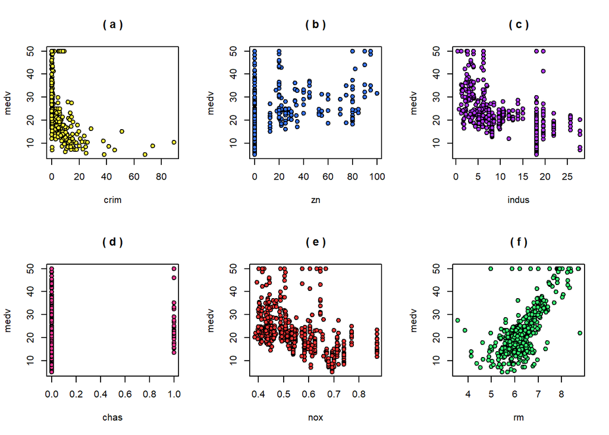

```r
par(mfrow=c(2,3))
set.seed(5)
colours= sample(rainbow(13,s=0.8))
predictors=names(Boston)

for(i in 1:6){
  plot(Boston[,i],Boston[,14],xlab=predictors[i],ylab = "medv",pch=21,col='black',
       bg=colours[i], main=paste("(",letters[i],")"))
}
```

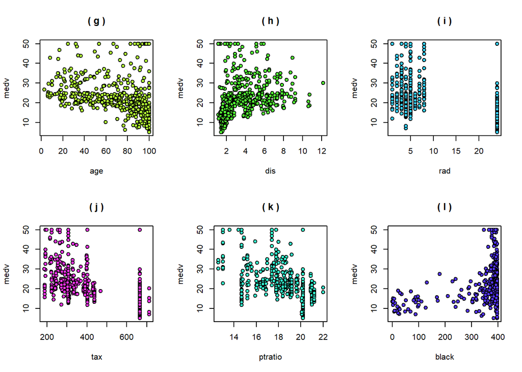

```r
par(mfrow=c(2,3))
for(i in 7:12){
  plot(Boston[,i],Boston[,14],xlab=predictors[i],ylab = "medv",pch=21,col='black',
       bg=colours[i], main=paste("(",letters[i],")"))
}
```

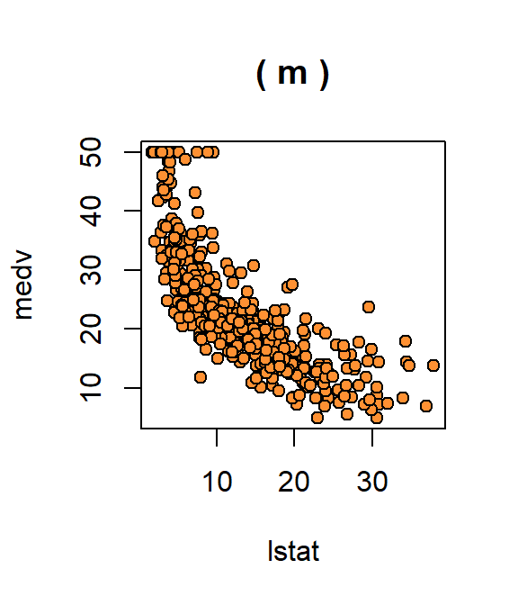

```r
par(mfrow=c(1,1))
plot(Boston[,13],Boston[,14], xlab=predictors[13],ylab = "medv",pch=21,col='black',
       bg=colours[13], main=paste("(",letters[13],")"))
```

3. **Are any of the predictors asociated with per capita crime rate? If so, explain the relationship.**

En este apartado se pretenden analizar asociaciones de variables con la variable *crime rate*, por tanto, consideramos *crime rate* la variable dependiente. Para determinar los predictores podemos hacer unas gráficas iniciales, y así observar el comportamiento entre las variables.

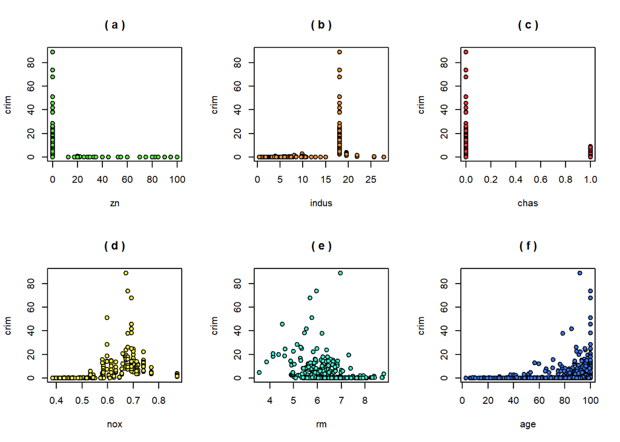

```r
par(mfrow=c(2,3))
set.seed(7)
colours= sample(rainbow(13,s=0.8))
for(i in 2:7){
  plot(Boston[,i],Boston[,1],xlab=predictors[i],ylab = "crim",pch=21,col='black',
       bg=colours[i], main=paste("(",letters[i-1],")"))
}
```

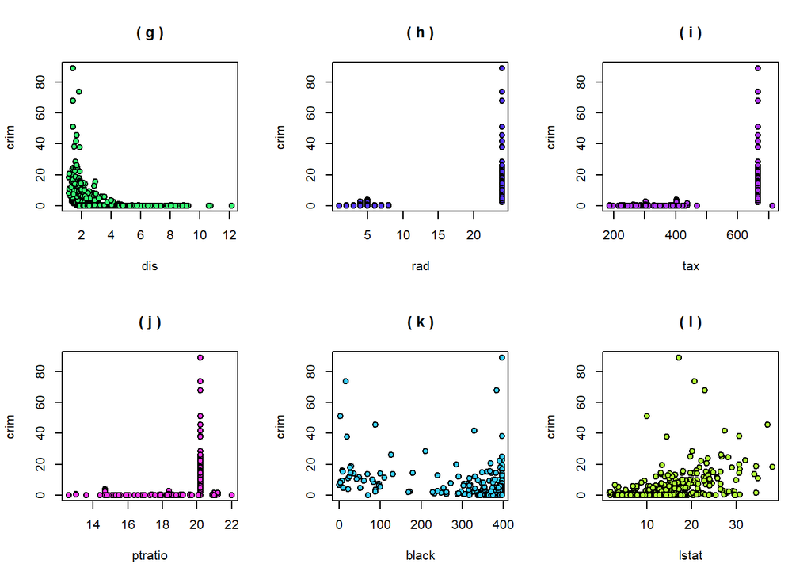

```r
par(mfrow=c(2,3))
for(i in 8:13){
  plot(Boston[,i],Boston[,1],xlab=predictors[i],ylab = "crim",pch=21,col='black',
       bg=colours[i], main=paste("(",letters[i-1],")"))
}
```

Notemos que no se ha dibujado la gráfica *crim* vs *medv*, ya que se corresponde con la gráfica **(a)** del apartado anterior. Como se ha comentado, sí parece haber relación entre estas variables. Por otra parte, la variable *crim* también se podría asociar con **(g)** *dis*.

Así, primero vamos a realizar una regresión cuadrática, con *medv* la variable predictora.

```r
lm_medv=lm(crim~poly(medv ,2),data=Boston)
summary(lm_medv)
```

```
##
## Call:
## lm(formula = crim ~ poly(medv, 2), data = Boston)
##
## Residuals:
##     Min      1Q  Median      3Q     Max
## -18.802  -3.127  -0.593   2.031  75.204
##
## Coefficients:
##                Estimate Std. Error t value Pr(>|t|)
## (Intercept)      3.6135     0.3069   11.78   <2e-16 ***
## poly(medv, 2)1 -75.0576     6.9033  -10.87   <2e-16 ***
## poly(medv, 2)2  88.0862     6.9033   12.76   <2e-16 ***
## ---
## Signif. codes:  0 '***' 0.001 '**' 0.01 '*' 0.05 '.' 0.1 ' ' 1
##
## Residual standard error: 6.903 on 503 degrees of freedom
## Multiple R-squared:  0.3584, Adjusted R-squared:  0.3559
## F-statistic: 140.5 on 2 and 503 DF,  p-value: < 2.2e-16
```

Sean $H_0: \beta_i =0$, $i=0,1,2$, los contrastes de hipótesis para los coeficientes $\beta_0$, $\beta_1$ y $\beta_2$ de la regresión cuadrática, tenemos que el p-valor asociado a cada contraste es muy pequeño. Por tanto, rechazamos la hipótesis nula y decimos que los coeficientes estimados son significativamente diferentes de cero. A continuación, tenemos la función del modelo estimada.

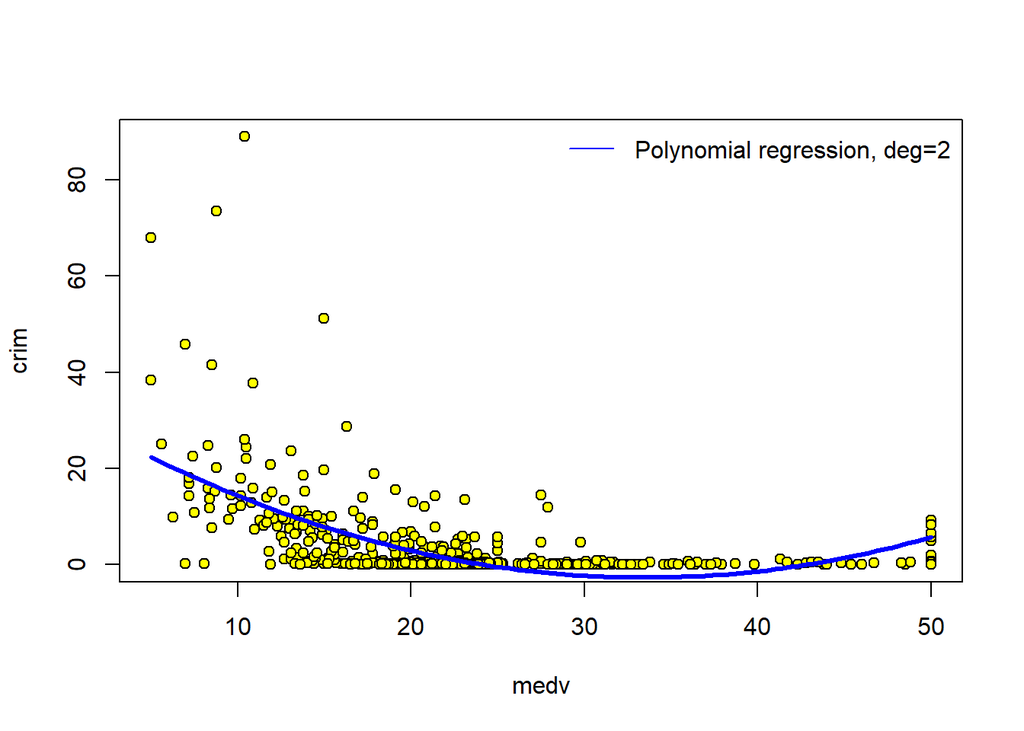

```r
par(mfrow=c(1,1))
attach(Boston)
plot(Boston$medv, Boston$crim, xlab = "medv", ylab = "crim", pch=21,
     col ="black",bg='yellow')
curve(predict(lm_medv,data.frame(medv=x)),col='blue',lwd=3,add=TRUE)
legend("topright",legend="Polynomial regression, deg=2",col="blue",lty =1,bty ="n")
```

La función del modelo estimada sugiere que la tasa de criminalidad disminuye a medida que aumenta el valor medio de las viviendas, aunque a partir de cierto valor cercano a 35000 la tasa se incrementa.

Para la variable **(g)** *dis* también podemos realizar regresión cuadrática.

```r
lm_dis=lm(crim~poly(dis ,2))
summary(lm_dis)
```

```
##
## Call:
## lm(formula = crim ~ poly(dis, 2))
##
## Residuals:
##     Min      1Q  Median      3Q     Max
## -12.896  -3.721  -0.229   1.736  78.724
##
## Coefficients:
##               Estimate Std. Error t value Pr(>|t|)
## (Intercept)     3.6135     0.3364  10.742  < 2e-16 ***
## poly(dis, 2)1 -73.3886     7.5667  -9.699  < 2e-16 ***
## poly(dis, 2)2  56.3730     7.5667   7.450 4.09e-13 ***
## ---
## Signif. codes:  0 '***' 0.001 '**' 0.01 '*' 0.05 '.' 0.1 ' ' 1
##
## Residual standard error: 7.567 on 503 degrees of freedom
## Multiple R-squared:  0.2292, Adjusted R-squared:  0.2261
## F-statistic: 74.79 on 2 and 503 DF,  p-value: < 2.2e-16
```

De nuevo, mirando el p-valor, obtenemos que los coeficientes són diferentes de cero significativamente. La función de aproximación en este caso es la siguiente.

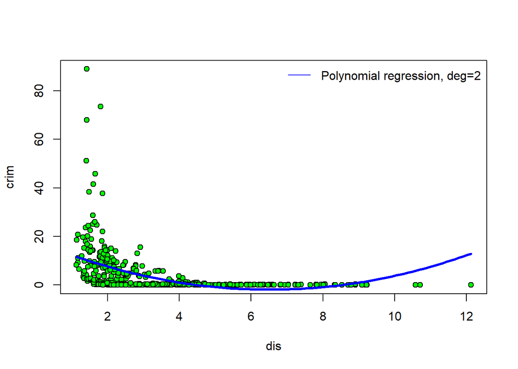

```r
plot(Boston$dis, Boston$crim, xlab = "dis", ylab = "crim", pch=21,
     col ="black",bg='green')
curve(predict(lm_dis,data.frame(dis=x)),col='blue',lwd=3,add=TRUE)
legend("topright",legend="Polynomial regression, deg=2",col="blue",lty =1,bty ="n")
```

Probemos con un polinomio de grado 3.

```r
lm_dis3=lm(crim~poly(dis ,3))
summary(lm_dis3)
```

```
##
## Call:
## lm(formula = crim ~ poly(dis, 3))
##
## Residuals:
##     Min      1Q  Median      3Q     Max
## -10.757  -2.588   0.031   1.267  76.378
##
## Coefficients:
##               Estimate Std. Error t value Pr(>|t|)
## (Intercept)     3.6135     0.3259  11.087  < 2e-16 ***
## poly(dis, 3)1 -73.3886     7.3315 -10.010  < 2e-16 ***
## poly(dis, 3)2  56.3730     7.3315   7.689 7.87e-14 ***
## poly(dis, 3)3 -42.6219     7.3315  -5.814 1.09e-08 ***
## ---
## Signif. codes:  0 '***' 0.001 '**' 0.01 '*' 0.05 '.' 0.1 ' ' 1
##
## Residual standard error: 7.331 on 502 degrees of freedom
## Multiple R-squared:  0.2778, Adjusted R-squared:  0.2735
## F-statistic: 64.37 on 3 and 502 DF,  p-value: < 2.2e-16
```

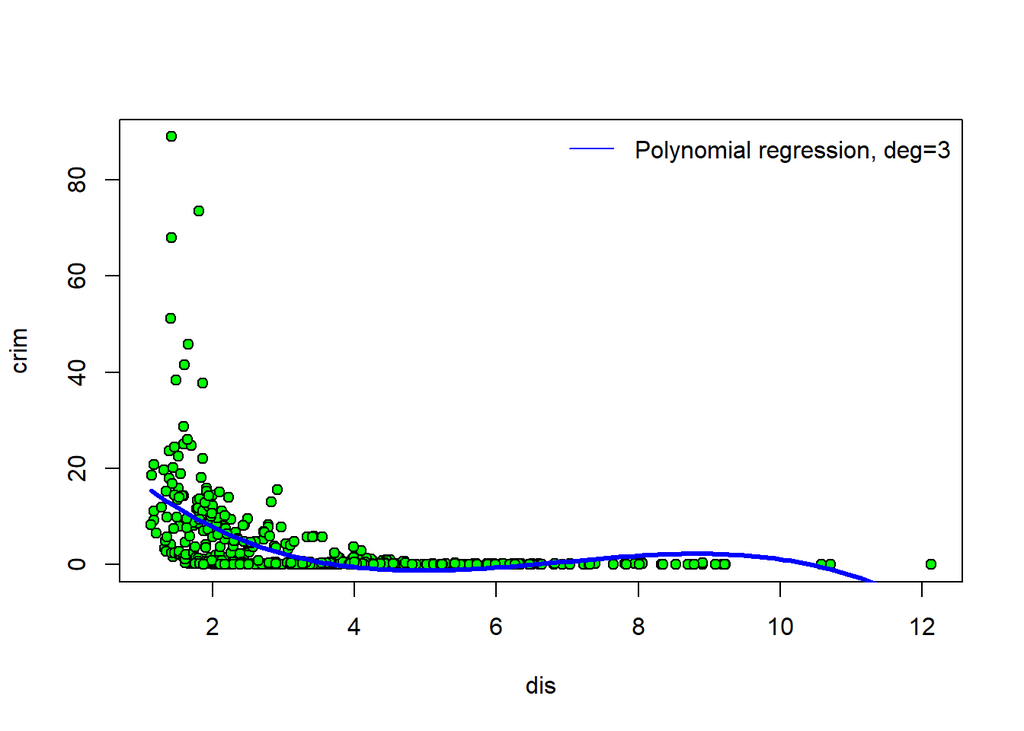

```r
plot(Boston$dis, Boston$crim, xlab = "dis", ylab = "crim", pch=21,
     col ="black",bg='green')
curve(predict(lm_dis3,data.frame(dis=x)),col='blue',lwd=3,add=TRUE)
legend("topright",legend="Polynomial regression, deg=3",col="blue",lty =1,bty ="n")
```

Comparemos los errores cuadráticos medios.

```r
MSE_dis2=mean(lm_dis$residuals^2)
MSE_dis3=mean(lm_dis3$residuals^2)

MSE_dis2
```

```
## [1] 56.91585
```

```r
MSE_dis3
```

```
## [1] 53.32568
```

El error cuadrático es menor usando un polinomio de grado 3, aunque con poca diferencia. Cuanto a los coeficientes, de nuevo estan asociados con un p-valor muy pequeño. Además, los resultados parecen indicar que la tasa de criminalidad es mayor cerca de los cinco centros de empleo de Boston.

Una vez observadas algunas relaciones por pares, vamos a realizar regresión lineal de *crim* con todas las demás variables.

```r
lm_all=lm(crim~., data=Boston)
summary(lm_all)
```

```
##
## Call:
## lm(formula = crim ~ ., data = Boston)
##
## Residuals:
##    Min     1Q Median     3Q    Max
## -9.924 -2.120 -0.353  1.019 75.051
##
## Coefficients:
##               Estimate Std. Error t value Pr(>|t|)
## (Intercept)  17.033228   7.234903   2.354 0.018949 *
## zn            0.044855   0.018734   2.394 0.017025 *
## indus        -0.063855   0.083407  -0.766 0.444294
## chas         -0.749134   1.180147  -0.635 0.525867
## nox         -10.313535   5.275536  -1.955 0.051152 .
## rm            0.430131   0.612830   0.702 0.483089
## age           0.001452   0.017925   0.081 0.935488
## dis          -0.987176   0.281817  -3.503 0.000502 ***
## rad           0.588209   0.088049   6.680 6.46e-11 ***
## tax          -0.003780   0.005156  -0.733 0.463793
## ptratio      -0.271081   0.186450  -1.454 0.146611
## black        -0.007538   0.003673  -2.052 0.040702 *
## lstat         0.126211   0.075725   1.667 0.096208 .
## medv         -0.198887   0.060516  -3.287 0.001087 **
## ---
## Signif. codes:  0 '***' 0.001 '**' 0.01 '*' 0.05 '.' 0.1 ' ' 1
##
## Residual standard error: 6.439 on 492 degrees of freedom
## Multiple R-squared:  0.454,  Adjusted R-squared:  0.4396
## F-statistic: 31.47 on 13 and 492 DF,  p-value: < 2.2e-16
```

Notemos que los p-valores más pequeños corresponden precisamente con las variables *dis* y *medv*, que hemos estudiado anteriormente por separado, y la variable *rad*. También parecen afectar significativamente *zn* y *black*. Así, se observa una relación lineal de *crim* con estas variables.

4. **Do any of the suburbs of Boston appear to have particularly high crime rates? Tax rates? Pupil-teacher ratios? Comment on the range of each predictor.**

Para responder estas preguntas hacemos *summary* de las variables *crim*, *tax* y *ptratio*.

```r
summary(Boston[,c("crim","tax","ptratio")])
```

```
##       crim               tax           ptratio
##  Min.   : 0.00632   Min.   :187.0   Min.   :12.60
##  1st Qu.: 0.08204   1st Qu.:279.0   1st Qu.:17.40
##  Median : 0.25651   Median :330.0   Median :19.05
##  Mean   : 3.61352   Mean   :408.2   Mean   :18.46
##  3rd Qu.: 3.67708   3rd Qu.:666.0   3rd Qu.:20.20
##  Max.   :88.97620   Max.   :711.0   Max.   :22.00
```

Esta información se puede representar en un diagrama de cajas, tal como sigue.

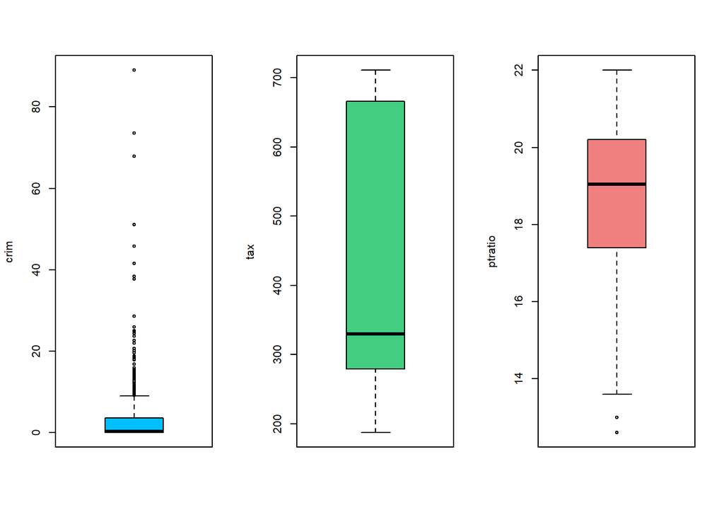

```r
par(mfrow=c(1,3))
boxplot(Boston[,c("crim")],ylab="crim",col="deepskyblue")
boxplot(Boston[,c("tax")],ylab="tax",col="seagreen3")
boxplot(Boston[,c("ptratio")],ylab="ptratio",col="lightcoral")
```

Por otra parte, no hay ninguna tasa de impuesto o proporción profesor-alumno que supere el valor $Q_3+1.5\cdot IQR$. Esto no ocurre con la tasa de criminalidad, así, seleccionamos los barrios que tienen una tasa mayor que este valor.

```r
high_crime=Boston[,c("crim")]>3.67700+(3.67700-0.08204)*1.5
high_crime=Boston[high_crime,]
high_crime
```

| crim | zn | indus | chas | nox | rm | age | dis | rad | tax | ptratio | black | lstat | medv |
| --- | --- | --- | --- | --- | --- | --- | --- | --- | --- | --- | --- | --- | --- |
| 13.52220 | 0 | 18.1 | 0 | 0.631 | 3.863 | 100.0 | 1.5106 | 24 | 666 | 20.2 | 131.42 | 13.33 | 23.1 |
| 9.23230 | 0 | 18.1 | 0 | 0.631 | 6.216 | 100.0 | 1.1691 | 24 | 666 | 20.2 | 366.15 | 9.53 | 50.0 |
| 11.10810 | 0 | 18.1 | 0 | 0.668 | 4.906 | 100.0 | 1.1742 | 24 | 666 | 20.2 | 396.90 | 34.77 | 13.8 |
| 18.49820 | 0 | 18.1 | 0 | 0.668 | 4.138 | 100.0 | 1.1370 | 24 | 666 | 20.2 | 396.90 | 37.97 | 13.8 |
| 19.60910 | 0 | 18.1 | 0 | 0.671 | 7.313 | 97.9 | 1.3163 | 24 | 666 | 20.2 | 396.90 | 13.44 | 15.0 |
| 15.28800 | 0 | 18.1 | 0 | 0.671 | 6.649 | 93.3 | 1.3449 | 24 | 666 | 20.2 | 363.02 | 23.24 | 13.9 |
| 9.82349 | 0 | 18.1 | 0 | 0.671 | 6.794 | 98.8 | 1.3580 | 24 | 666 | 20.2 | 396.90 | 21.24 | 13.3 |
| 23.64820 | 0 | 18.1 | 0 | 0.671 | 6.380 | 96.2 | 1.3861 | 24 | 666 | 20.2 | 396.90 | 23.69 | 13.1 |
| 17.86670 | 0 | 18.1 | 0 | 0.671 | 6.223 | 100.0 | 1.3861 | 24 | 666 | 20.2 | 393.74 | 21.78 | 10.2 |
| 88.97620 | 0 | 18.1 | 0 | 0.671 | 6.968 | 91.9 | 1.4165 | 24 | 666 | 20.2 | 396.90 | 17.21 | 10.4 |

[output cut: 56 more lines]

Dada la gran cantidad de barrios seleccionados, supongamos que sólo nos interesa conocer los 10 barrios con una mayor tasa de criminalidad. De esta manera, basta obtener los índices del *data frame* high_crime ordenado por *crim*.

```r
idx=order(high_crime$crim, decreasing = TRUE)
high_crime[idx[1:10],]
```

| crim | zn | indus | chas | nox | rm | age | dis | rad | tax | ptratio | black | lstat | medv |
| --- | --- | --- | --- | --- | --- | --- | --- | --- | --- | --- | --- | --- | --- |
| 88.9762 | 0 | 18.1 | 0 | 0.671 | 6.968 | 91.9 | 1.4165 | 24 | 666 | 20.2 | 396.90 | 17.21 | 10.4 |
| 73.5341 | 0 | 18.1 | 0 | 0.679 | 5.957 | 100.0 | 1.8026 | 24 | 666 | 20.2 | 16.45 | 20.62 | 8.8 |
| 67.9208 | 0 | 18.1 | 0 | 0.693 | 5.683 | 100.0 | 1.4254 | 24 | 666 | 20.2 | 384.97 | 22.98 | 5.0 |
| 51.1358 | 0 | 18.1 | 0 | 0.597 | 5.757 | 100.0 | 1.4130 | 24 | 666 | 20.2 | 2.60 | 10.11 | 15.0 |
| 45.7461 | 0 | 18.1 | 0 | 0.693 | 4.519 | 100.0 | 1.6582 | 24 | 666 | 20.2 | 88.27 | 36.98 | 7.0 |
| 41.5292 | 0 | 18.1 | 0 | 0.693 | 5.531 | 85.4 | 1.6074 | 24 | 666 | 20.2 | 329.46 | 27.38 | 8.5 |
| 38.3518 | 0 | 18.1 | 0 | 0.693 | 5.453 | 100.0 | 1.4896 | 24 | 666 | 20.2 | 396.90 | 30.59 | 5.0 |
| 37.6619 | 0 | 18.1 | 0 | 0.679 | 6.202 | 78.7 | 1.8629 | 24 | 666 | 20.2 | 18.82 | 14.52 | 10.9 |
| 28.6558 | 0 | 18.1 | 0 | 0.597 | 5.155 | 100.0 | 1.5894 | 24 | 666 | 20.2 | 210.97 | 20.08 | 16.3 |
| 25.9406 | 0 | 18.1 | 0 | 0.679 | 5.304 | 89.1 | 1.6475 | 24 | 666 | 20.2 | 127.36 | 26.64 | 10.4 |

5. **How many of the suburbs in this data set bound the Charles river?**

La variable *chas* toma valores en $\{0,1\}$, donde $1$ denota que el barrio correspondiente está delimitado por el rio Charles. Por tanto, para conocer el número de barrios que lindan con éste rio basta contar los unos.

```r
sum(Boston$chas)
```

```
## [1] 35
```

Así, hay 35 barrios que lindan con el rio Charles.

6. **What is the median pupil-teacher ratio among the towns in this data set?**

La función *mean* de **R** permite calcular la media de la columna *ptratio*, tal como sigue.

```r
mean(Boston$ptratio)
```

```
## [1] 18.45553
```

Entonces, la media de alumno por profesor es de 18.45553 alumnos.

7. **Which suburb of Boston has lowest median value of owneroccupied homes? What are the values of the other predictors for that suburb, and how do those values compare to the overall ranges for those predictors? Comment on your findings.**

Para conocer el mínimo de *medv*, el valor medio de las viviendas ocupadas, podemos usar la función *min*.

```r
min_medv=min(Boston$medv)
min_medv
```

```
## [1] 5
```

Así, para conocer que barrios tienen este valor medio, basta seleccionar las filas con $medv$=5.

```r
Boston[Boston$medv == min_medv,]
```

| crim | zn | indus | chas | nox | rm | age | dis | rad | tax | ptratio | black | lstat | medv |
| --- | --- | --- | --- | --- | --- | --- | --- | --- | --- | --- | --- | --- | --- |
| 38.3518 | 0 | 18.1 | 0 | 0.693 | 5.453 | 100 | 1.4896 | 24 | 666 | 20.2 | 396.90 | 30.59 | 5 |
| 67.9208 | 0 | 18.1 | 0 | 0.693 | 5.683 | 100 | 1.4254 | 24 | 666 | 20.2 | 384.97 | 22.98 | 5 |

A continuación hacemos *summary* de *medv* para comparar el valor de las variables para estos dos barrios con los demás.

```r
summary(Boston$medv)
```

```
##    Min. 1st Qu.  Median    Mean 3rd Qu.    Max.
##    5.00   17.02   21.20   22.53   25.00   50.00
```

Como podemos observar, los valores estan en el intervalo $[5,50]$. Este intevalo es muy amplio, por lo que el mínimo y el máximo estan muy alejados. De hecho, el valor medio de las viviendas ocupadas en estos barrios se aleja mucho de la media. Aún así, el valor mínimo no excede $Q_2-1.5\cdot IQR$. Veamos el diagrama de cajas.

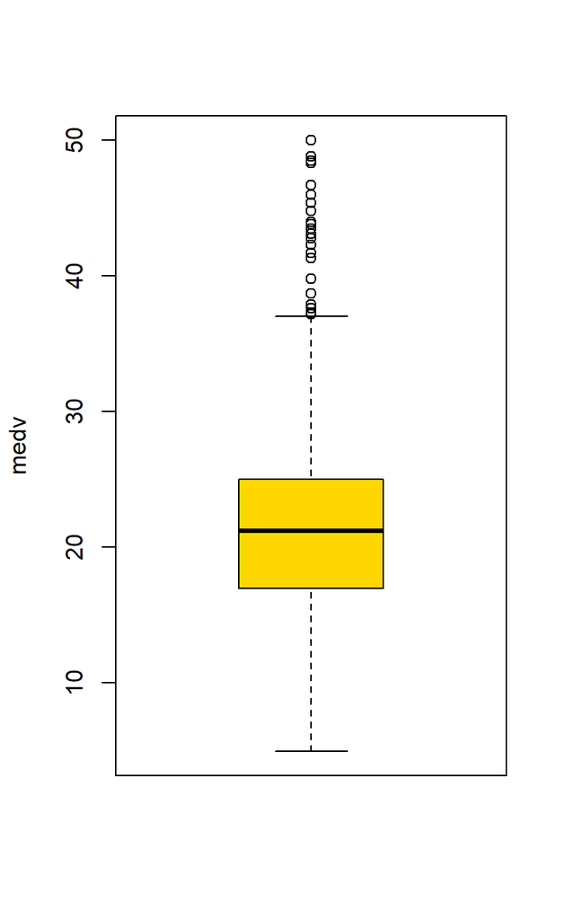

```r
par(mfrow=c(1,1))
boxplot(Boston[,c("medv")],ylab="medv",col="gold")
```

8. **In this data set, how many of the suburbs average more than seven rooms per dwelling? More than eight rooms per dwelling? Comment on the suburbs that average more than eight rooms per dwelling.**

Veamos cuantas filas, es decir, que barrios, tienen más de 7 habitaciones por vivienda en promedio.

```r
dim(Boston[Boston$rm>7,])[1]
```

```
## [1] 64
```

Si queremos ver la información correspondiente a estos 64 barrios, basta ejecutar la siguiente instrucción.

```r
Boston[Boston$rm>7,]
```

| crim | zn | indus | chas | nox | rm | age | dis | rad | tax | ptratio | black | lstat | medv |
| --- | --- | --- | --- | --- | --- | --- | --- | --- | --- | --- | --- | --- | --- |
| 0.02729 | 0.0 | 7.07 | 0 | 0.4690 | 7.185 | 61.1 | 4.9671 | 2 | 242 | 17.8 | 392.83 | 4.03 | 34.7 |
| 0.06905 | 0.0 | 2.18 | 0 | 0.4580 | 7.147 | 54.2 | 6.0622 | 3 | 222 | 18.7 | 396.90 | 5.33 | 36.2 |
| 0.03359 | 75.0 | 2.95 | 0 | 0.4280 | 7.024 | 15.8 | 5.4011 | 3 | 252 | 18.3 | 395.62 | 1.98 | 34.9 |
| 0.01311 | 90.0 | 1.22 | 0 | 0.4030 | 7.249 | 21.9 | 8.6966 | 5 | 226 | 17.9 | 395.93 | 4.81 | 35.4 |
| 0.01951 | 17.5 | 1.38 | 0 | 0.4161 | 7.104 | 59.5 | 9.2229 | 3 | 216 | 18.6 | 393.24 | 8.05 | 33.0 |
| 0.05660 | 0.0 | 3.41 | 0 | 0.4890 | 7.007 | 86.3 | 3.4217 | 2 | 270 | 17.8 | 396.90 | 5.50 | 23.6 |
| 0.05302 | 0.0 | 3.41 | 0 | 0.4890 | 7.079 | 63.1 | 3.4145 | 2 | 270 | 17.8 | 396.06 | 5.70 | 28.7 |
| 0.12083 | 0.0 | 2.89 | 0 | 0.4450 | 8.069 | 76.0 | 3.4952 | 2 | 276 | 18.0 | 396.90 | 4.21 | 38.7 |
| 0.08187 | 0.0 | 2.89 | 0 | 0.4450 | 7.820 | 36.9 | 3.4952 | 2 | 276 | 18.0 | 393.53 | 3.57 | 43.8 |
| 0.06860 | 0.0 | 2.89 | 0 | 0.4450 | 7.416 | 62.5 | 3.4952 | 2 | 276 | 18.0 | 396.90 | 6.19 | 33.2 |

[output cut: 54 more lines]

Ahora, veamos cuantos barrios tienen un valor de $rm$ mayor que $8$.

```r
dim(Boston[Boston$rm>8,])[1]
```

```
## [1] 13
```

Y la información de los 13 barrios.

```r
Boston[Boston$rm>8,]
```

| crim | zn | indus | chas | nox | rm | age | dis | rad | tax | ptratio | black | lstat | medv |
| --- | --- | --- | --- | --- | --- | --- | --- | --- | --- | --- | --- | --- | --- |
| 0.12083 | 0 | 2.89 | 0 | 0.4450 | 8.069 | 76.0 | 3.4952 | 2 | 276 | 18.0 | 396.90 | 4.21 | 38.7 |
| 1.51902 | 0 | 19.58 | 1 | 0.6050 | 8.375 | 93.9 | 2.1620 | 5 | 403 | 14.7 | 388.45 | 3.32 | 50.0 |
| 0.02009 | 95 | 2.68 | 0 | 0.4161 | 8.034 | 31.9 | 5.1180 | 4 | 224 | 14.7 | 390.55 | 2.88 | 50.0 |
| 0.31533 | 0 | 6.20 | 0 | 0.5040 | 8.266 | 78.3 | 2.8944 | 8 | 307 | 17.4 | 385.05 | 4.14 | 44.8 |
| 0.52693 | 0 | 6.20 | 0 | 0.5040 | 8.725 | 83.0 | 2.8944 | 8 | 307 | 17.4 | 382.00 | 4.63 | 50.0 |
| 0.38214 | 0 | 6.20 | 0 | 0.5040 | 8.040 | 86.5 | 3.2157 | 8 | 307 | 17.4 | 387.38 | 3.13 | 37.6 |
| 0.57529 | 0 | 6.20 | 0 | 0.5070 | 8.337 | 73.3 | 3.8384 | 8 | 307 | 17.4 | 385.91 | 2.47 | 41.7 |
| 0.33147 | 0 | 6.20 | 0 | 0.5070 | 8.247 | 70.4 | 3.6519 | 8 | 307 | 17.4 | 378.95 | 3.95 | 48.3 |
| 0.36894 | 22 | 5.86 | 0 | 0.4310 | 8.259 | 8.4 | 8.9067 | 7 | 330 | 19.1 | 396.90 | 3.54 | 42.8 |
| 0.61154 | 20 | 3.97 | 0 | 0.6470 | 8.704 | 86.9 | 1.8010 | 5 | 264 | 13.0 | 389.70 | 5.12 | 50.0 |

[output cut: 3 more lines]

Para comparar la información, calculemos los intervalos de las variables y la media de los valores que toman las variables de los barrios seleccionados.

```r
sapply(Boston, range)
```

```
##          crim  zn indus chas   nox    rm   age     dis rad tax ptratio
## [1,]  0.00632   0  0.46    0 0.385 3.561   2.9  1.1296   1 187    12.6
## [2,] 88.97620 100 27.74    1 0.871 8.780 100.0 12.1265  24 711    22.0
##       black lstat medv
## [1,]   0.32  1.73    5
## [2,] 396.90 37.97   50
```

```r
sapply (Boston[Boston$rm>8,], mean)
```

```
##        crim          zn       indus        chas         nox          rm
##   0.7187954  13.6153846   7.0784615   0.1538462   0.5392385   8.3485385
##         age         dis         rad         tax     ptratio       black
##  71.5384615   3.4301923   7.4615385 325.0769231  16.3615385 385.2107692
##       lstat        medv
##   4.3100000  44.2000000
```

Notemos que los barrios seleccionados por un número de habitaciones mayor que 8 en promedio, tienen un valor medio de las viviendas ocupadas elevado, en general. Lo mismo ocurre con la proporción de viviendas ocupadas construidas antes de 1940 (*age*).

En el apartado **(b)** hay una gráfica, **(f)**, que muestra la aparente relación lineal entre *medv* y *rm*. Así, podemos realizar regressión lineal entre estas variables.

```r
lm_rm=lm(medv~rm)
summary(lm_rm)
```

```
##
## Call:
## lm(formula = medv ~ rm)
##
## Residuals:
##     Min      1Q  Median      3Q     Max
## -23.346  -2.547   0.090   2.986  39.433
##
## Coefficients:
##             Estimate Std. Error t value Pr(>|t|)
## (Intercept)  -34.671      2.650  -13.08   <2e-16 ***
## rm             9.102      0.419   21.72   <2e-16 ***
## ---
## Signif. codes:  0 '***' 0.001 '**' 0.01 '*' 0.05 '.' 0.1 ' ' 1
##
## Residual standard error: 6.616 on 504 degrees of freedom
## Multiple R-squared:  0.4835, Adjusted R-squared:  0.4825
## F-statistic: 471.8 on 1 and 504 DF,  p-value: < 2.2e-16
```

Notemos que el p-valor asociado a cada coeficiente permite rechazar la hipòtesis nula, y por tanto decimos que hay una relación lineal entre ambas variables.

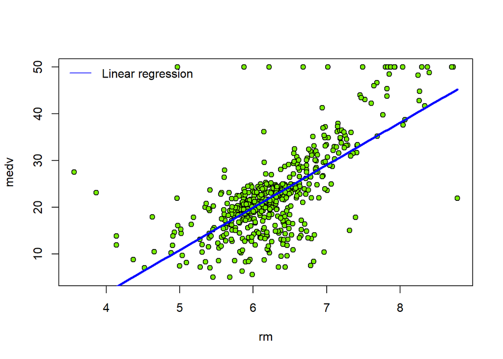

```r
plot(Boston$rm, Boston$medv, xlab = "rm", ylab = "medv", pch=21,
     col ="black",bg='chartreuse2')
curve(predict(lm_rm,data.frame(rm=x)),col='blue',lwd=3,add=TRUE)
legend("topleft",legend="Linear regression",col="blue",lty =1,bty ="n")
```

Ahora, veamos como es la grafica de *rm* vs *age*.

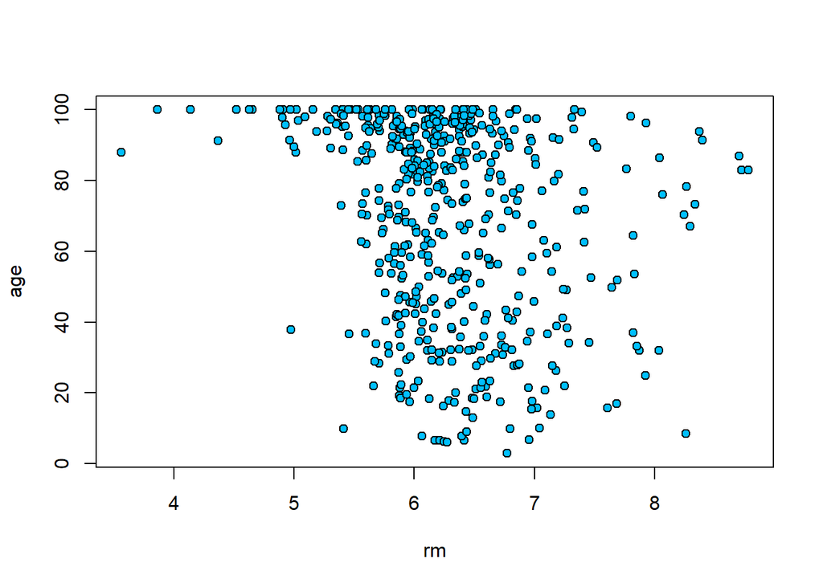

```r
plot(Boston$rm, Boston$age, xlab = "rm", ylab = "age", pch=21,
     col ="black",bg='deepskyblue')
```

En este caso, no parece haber ningúna relación entre las variables. Si calculamos el coeficiente de correlación, vemos que éste es pequeño en términos absolutos.

```r
cor(Boston$rm,Boston$age)
```

```
## [1] -0.2402649
```

## Exercice 6

**Vamos a utilizar un conjunto de datos de 100 pacientes para implementar el algoritmo KNN. El conjunto de datos se ha elaborado teniendo en cuenta los resultados obtenidos generalmente por el examen rectal digital. Utilice los datos Pro.csv. Proporcione el código y los resultados de los siguientes apartados:**

1. **Cargue los datos y analícelos. Haz una tabla con los pacientes que tuvieron un resultado Malignant (M) y Benign (B).**

```r
rm(list = ls())
Pro = read.csv("Pro.csv")

Pro_Malignant = Pro[Pro$diagnosis_result == "M", ]
Pro_Benign = Pro[Pro$diagnosis_result == "B", ]
head(Pro_Malignant)
```

| id | diagnosis_result | radius | texture | perimeter | area | smoothness | compactness | symmetry | fractal_dimension |
| --- | --- | --- | --- | --- | --- | --- | --- | --- | --- |
| 1 | M | 23 | 12 | 151 | 954 | 0.143 | 0.278 | 0.242 | 0.079 |
| 3 | M | 21 | 27 | 130 | 1203 | 0.125 | 0.160 | 0.207 | 0.060 |
| 4 | M | 14 | 16 | 78 | 386 | 0.070 | 0.284 | 0.260 | 0.097 |
| 5 | M | 9 | 19 | 135 | 1297 | 0.141 | 0.133 | 0.181 | 0.059 |
| 7 | M | 16 | 26 | 120 | 1040 | 0.095 | 0.109 | 0.179 | 0.057 |
| 8 | M | 15 | 18 | 90 | 578 | 0.119 | 0.165 | 0.220 | 0.075 |

```r
head(Pro_Benign)
```

| id | diagnosis_result | radius | texture | perimeter | area | smoothness | compactness | symmetry | fractal_dimension |
| --- | --- | --- | --- | --- | --- | --- | --- | --- | --- |
| 2 | B | 9 | 13 | 133 | 1326 | 0.143 | 0.079 | 0.181 | 0.057 |
| 6 | B | 25 | 25 | 83 | 477 | 0.128 | 0.170 | 0.209 | 0.076 |
| 13 | B | 14 | 15 | 132 | 1123 | 0.097 | 0.246 | 0.240 | 0.078 |
| 20 | B | 17 | 11 | 87 | 566 | 0.098 | 0.081 | 0.189 | 0.058 |
| 21 | B | 16 | 14 | 86 | 520 | 0.108 | 0.127 | 0.197 | 0.068 |
| 22 | B | 17 | 24 | 60 | 274 | 0.102 | 0.065 | 0.182 | 0.069 |

2. **Separe la muestra entre datos de entrenamiento y de prueba para predecir el resultado del tratamiento.**

```r
library(class)
set.seed(1234)
ind = sample(2, nrow(Pro), replace=TRUE, prob=c(0.67, 0.33))
Pro.training = Pro[ind==1,3:8]
Pro.test = Pro[ind==2,3:8]

Pro.trainLabels = Pro[ind==1,2]
Pro.testLabels = Pro[ind==2,2]
```

3. **Ajuste un modelo KNN y evalúe su desempeño.**

```r
Pro_pred = knn(train = Pro.training, test = Pro.test, cl = Pro.trainLabels, k=3)
library('gmodels')
ct = CrossTable(x = Pro.testLabels, y = Pro_pred, prop.chisq=FALSE)
```

```
##
##
##    Cell Contents
## |-------------------------|
## |                       N |
## |           N / Row Total |
## |           N / Col Total |
## |         N / Table Total |
## |-------------------------|
##
##
## Total Observations in Table:  24
##
##
##                | Pro_pred
## Pro.testLabels |         B |         M | Row Total |
## ---------------|-----------|-----------|-----------|
##              B |         7 |         1 |         8 |
##                |     0.875 |     0.125 |     0.333 |
##                |     0.875 |     0.062 |           |
##                |     0.292 |     0.042 |           |
## ---------------|-----------|-----------|-----------|
##              M |         1 |        15 |        16 |
##                |     0.062 |     0.938 |     0.667 |
##                |     0.125 |     0.938 |           |
##                |     0.042 |     0.625 |           |
## ---------------|-----------|-----------|-----------|
##   Column Total |         8 |        16 |        24 |
##                |     0.333 |     0.667 |           |
## ---------------|-----------|-----------|-----------|
##
##
```

```r
n_error = ct$t[2] + ct$t[3]
n_total = ct$t[1] + n_error + ct$t[4]
{ # Solo para que el HTML o PDF no genere un campo para cada línea de código
cat("Modelo KNN para K=3 \n")
cat("Nº de Error: ",n_error,"\n")
cat("Nº Total: ",n_total,"\n")
cat("Error de Prueba: ",n_error/n_total)
}
```

```
## Modelo KNN para K=3
## Nº de Error:  2
## Nº Total:  24
## Error de Prueba:  0.08333333
```

De la tabla podemos obtener que el error es de 2/24 = 0.08333333

4. **Repite el apartado (iii) para descubrir cúal elección de k en el KNN genera el menor error de prueba (con el k 2 [1; 12]).**

```r
for(i in 1:12){
  Pro_pred = knn(train = Pro.training, test = Pro.test, cl = Pro.trainLabels, k=i)
  n_total = length(Pro_pred)
  n_error = length(which(c(Pro_pred==Pro.testLabels)==FALSE))
  cat("Prueba K:",i,"\n")
  cat("Error de Prueba: ",n_error/n_total,"\n-----------------------------\n")
}
```

```
## Prueba K: 1
## Error de Prueba:  0.2916667
## -----------------------------
## Prueba K: 2
## Error de Prueba:  0.25
## -----------------------------
## Prueba K: 3
## Error de Prueba:  0.08333333
## -----------------------------
## Prueba K: 4
## Error de Prueba:  0.08333333
## -----------------------------
## Prueba K: 5
## Error de Prueba:  0.08333333
## -----------------------------
## Prueba K: 6
## Error de Prueba:  0.125
## -----------------------------
## Prueba K: 7
## Error de Prueba:  0.125
## -----------------------------
## Prueba K: 8
## Error de Prueba:  0.125
## -----------------------------
## Prueba K: 9
## Error de Prueba:  0.125
## -----------------------------
## Prueba K: 10
## Error de Prueba:  0.08333333
## -----------------------------
## Prueba K: 11
## Error de Prueba:  0.08333333
## -----------------------------
## Prueba K: 12
## Error de Prueba:  0.08333333
## -----------------------------
```